# An Introduction with Examples in R Principal Component Analysis:

## Amount of Variation Captured by the PCs in the Dataset

Take each eigenvalue and divide it by the total of all eigenvalues – the total variation in the dataset – then multiply by 100. This calculation yields a table with the percent variation for each PC.

```r
pc1.var <- 100*round(my.eigen$values[1]/sum(my.eigen$values), digits = 3)
pc2.var <- 100*round(my.eigen$values[2]/sum(my.eigen$values), digits = 3)
pc3.var <- 100*round(my.eigen$values[3]/sum(my.eigen$values), digits = 3)
pc4.var <- 100*round(my.eigen$values[4]/sum(my.eigen$values), digits = 3)

pc <- data.frame(PC = c("PC1", "PC2", "PC3", "PC4"),
                 Percentage = c(pc1.var, pc2.var, pc3.var, pc4.var))

kable(pc, caption = "Amount of Variation Captured by PCs") %>%
  kable_styling(bootstrap_options = c("striped", "hover", "condensed", "responsive"), full_width = F)
```

Amount of Variation Captured by PCs

| PC | Percentage |
| --- | --- |
| PC1 | 67.8 |
| PC2 | 19.0 |
| PC3 | 10.3 |
| PC4 | 2.9 |

The total variation should sum to ~100% depending on rounding error:

```r
sum(pc1.var, pc2.var, pc3.var, pc4.var)
```

```
## [1] 100
```

## What are the PCA “scores”?

Express the loadings and scaled data as matrices, then multiply them together. The result is a new matrix which expresses the data in terms of the PCs. These are the PCA *scores*.

```r
loadings <- my.eigen$vectors
my.scaled.matrix <- as.matrix(my.scaled.data)
# the function %*% is matrix multiplication
scores <- my.scaled.matrix %*% loadings
sd <- sqrt(my.eigen$values)
rownames(loadings) <- colnames(my.scaled.data)

kable(head(scores), caption = "PCA Scores - First Six Rows") %>%
  kable_styling(bootstrap_options = c("striped", "hover", "condensed", "responsive"),
                full_width = F)
```

PCA Scores - First Six Rows

| PC1 | PC2 | PC3 | PC4 |
| --- | --- | --- | --- |
| -2.2600333 | 0.4795785 | 0.1963305 | -0.0511398 |
| -1.2140895 | 1.0327956 | 0.0184971 | 0.0859329 |
| -2.9229522 | 0.7366524 | -0.3902236 | 0.5873086 |
| -1.0989536 | 1.0164286 | 0.0283129 | 0.0653717 |
| -0.5060125 | 1.8150422 | 0.8229882 | 0.6191984 |
| -0.3073533 | 0.8777547 | 0.0583005 | -0.0498082 |

# Accomplishing the PCA with Native R Functions

The function `prcomp` is the primary tool for PCA in base R.

```r
pca_morpho <- prcomp(morpho, center = TRUE, scale. = TRUE)

# Show the variables in the class "prcomp"
ls(pca_morpho)
```

```
## [1] "center"   "rotation" "scale"    "sdev"     "x"
```

Rotations are often referred to as the “loadings” of a PCA.

```r
pca_loadings <- pca_morpho$rotation
kable(pca_loadings, caption = "PCA Loadings") %>%
  kable_styling(bootstrap_options = c("striped", "hover", "condensed", "responsive"),
                full_width = F)
```

PCA Loadings

|  | PC1 | PC2 | PC3 | PC4 |
| --- | --- | --- | --- | --- |
| interoc | -0.4972563 | -0.2503917 | 0.8251161 | -0.0960398 |
| cwidth | -0.5318709 | -0.3465188 | -0.4947682 | -0.5935002 |
| clength | -0.5759897 | -0.0463106 | -0.2715924 | 0.7696290 |
| T.weight | -0.3715984 | 0.9028201 | 0.0250084 | -0.2149537 |

Summary output of the PCA:

```r
pca_summary <- summary(pca_morpho)$importance %>%
  as.data.frame()
kable(pca_summary, caption = "PCA Summary") %>%
  kable_styling(bootstrap_options = c("striped", "hover", "condensed", "responsive"), full_width = F)
```

PCA Summary

|  | PC1 | PC2 | PC3 | PC4 |
| --- | --- | --- | --- | --- |
| Standard deviation | 1.646338 | 0.872236 | 0.6424942 | 0.3405524 |
| Proportion of Variance | 0.677610 | 0.190200 | 0.1032000 | 0.0289900 |
| Cumulative Proportion | 0.677610 | 0.867810 | 0.9710100 | 1.0000000 |

## Orthogonality of PCs

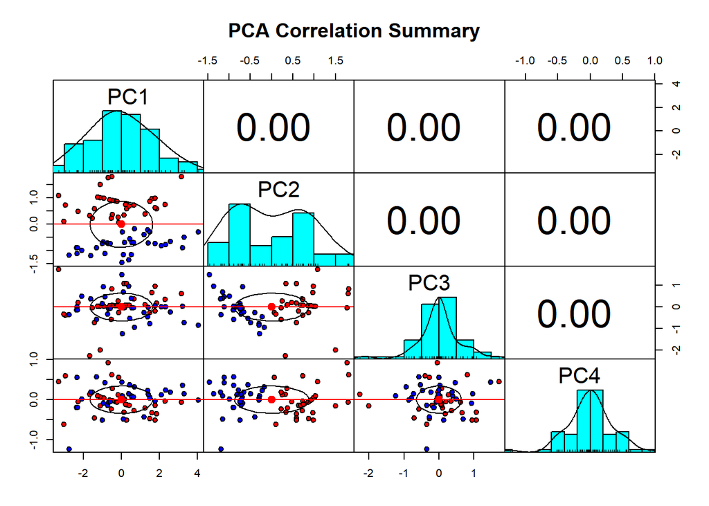

```r
pairs.panels(
  pca_morpho$x,
  main = "PCA Correlation Summary",
  gap = 0, # set to zero for no gap between plot panels
  lm = TRUE, # draw linear regression lines for pairs
  stars = TRUE, # display significance
  bg = c("red", "blue")[morpho_complete$sex], # color based on sex
  pch = 21) # data point shape
```

PCs are *orthogonal vectors*. Thus, the correlation coefficients equal zero for all possible pairwise combinations of PCs. Therefore, it is often used as a precursor to predictive modeling procedures as multicollinearity is eliminated.

## Biplot

The *biplot* is the primary visualization tool for PCA.

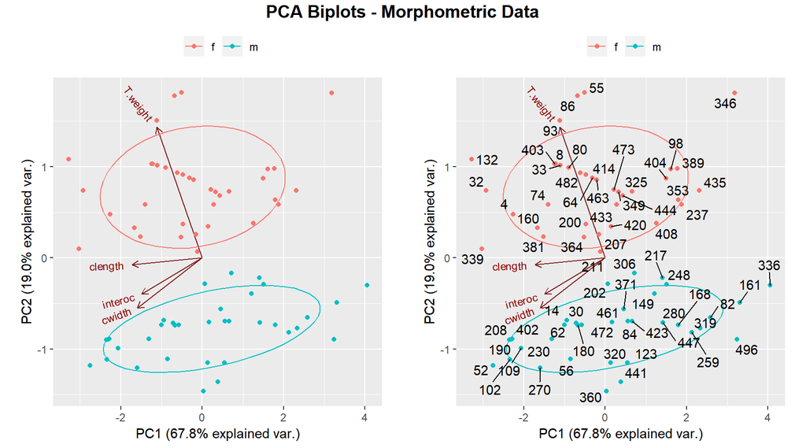

```r
# Plot without ID labels
g <- ggbiplot(pca_morpho,
              obs.scale = 1,
              var.scale = 1,
              groups = morpho_complete$sex,
              ellipse = TRUE,
              circle = FALSE,
              # draw ellipse around points (+/-) 1 standard deviation
              ellipse.prob = 0.68) +
  scale_color_discrete(name = '') +
  theme(legend.direction = "horizontal", legend.position = "top", aspect.ratio = 1)

# Plot with ID labels
h <- ggbiplot(pca_morpho,
              obs.scale = 1,
              var.scale = 1,
              groups = morpho_complete$sex,
              ellipse = TRUE,
              circle = FALSE,
              # draw ellipse around points (+/-) 1 standard deviation
              ellipse.prob = 0.68) +
  scale_color_discrete(name = '') +
  theme(legend.direction = "horizontal", legend.position = "top", aspect.ratio = 1) +
  geom_text_repel(aes(label = morpho_complete$id))

figure <- ggarrange(g, h, ncol = 2)

annotate_figure(figure,
               top = text_grob("PCA Biplots - Morphometric Data",
                               color = "black", face = "bold", size = 14),fig.lab.face = "bold")
```

## Interpreting the Biplot

Each variable in the dataset is plotted as a vector (red arrows). The cosine of the angle between any two vectors equals their correlation. For insatnce interoccular width and carapace width have a minimal angle between them, indicating high correlation.

Regarding carapace length, let’s look at spider ID#336 (male) and ID#339 (female):

```r
filter(morpho_complete, id == "336" | id == "339")
```

```
##    id sex interoc cwidth clength weight.mg T.weight
## 1 339   f   0.857  3.342   3.916      99.7 1.786258
## 2 336   m   0.676  2.723   3.341      42.4 1.681624
```

```r
paste("minimum carapace length =",
      min(morpho_complete$clength),
      "maximum carapace length =",
      max(morpho_complete$clength),
      sep = ' ')
```

```
## [1] "minimum carapace length = 3.336 maximum carapace length = 4.059"
```

Regarding weight, let’s look at spider ID#360 (male) and ID#55 (female):

```r
filter(morpho_complete, id == "360" | id == "55")
```

```
##    id sex interoc cwidth clength weight.mg T.weight
## 1  55   f   0.818  2.803   3.768     113.8 1.798779
## 2 360   m   0.870  2.909   3.688      46.5 1.695215
```

```r
paste("minimum weight =",
      min(morpho_complete$weight.mg),
      "maximum weight =",
      max(morpho_complete$weight.mg),
      sep = ' ')
```

```
## [1] "minimum weight = 39.8 maximum weight = 133.9"
```

## How many PCs can I retain to exp-lain “enough” variation?

Many methods have been propsed to answer this, but two are the most common: the Kaiser Criterion and Parallel Analysis.

### Kaiser Criterion

If an eigenvalue associated with a PC is $\small >1$, then you retain that component. To compute the eigenvalues from the PCA, square the standard deviations in the `prcomp` object.

```r
pca_morpho$sdev ^ 2
```

```
## [1] 2.7104296 0.7607956 0.4127988 0.1159759
```

The reason this works: the sum of the eigenvalues is equal to the total variance in the dataset. Only the first eigenvalue is $\small >1$, so according to the Kaiser Criterion, PC1 is sufficient to explain the variation in the dataset.

### Parallel Analysis

Parallel analysis is a technique designed to reduce the subjectivity of interpreting a *scree plot*.

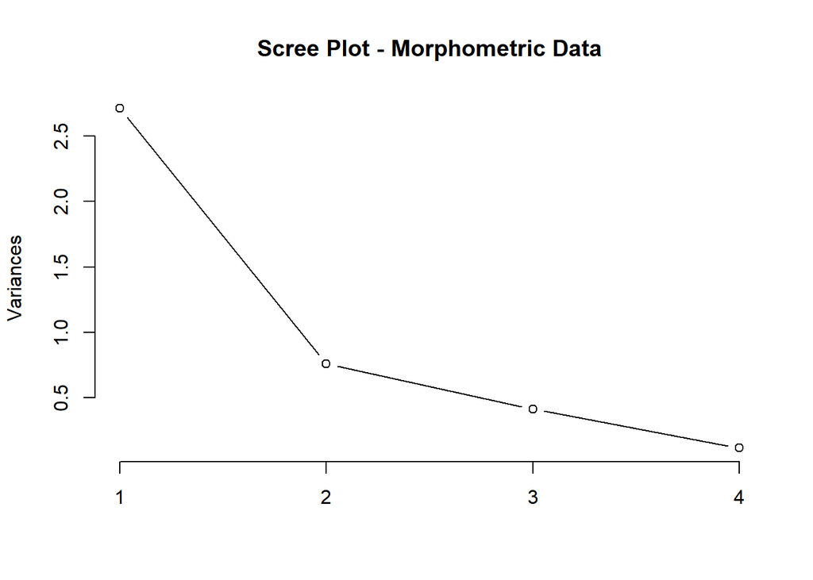

```r
screeplot(pca_morpho, type = "line", main = "Scree Plot - Morphometric Data")
```

A standard visual method is to choose the point which creates the most extreme “elbow” and retain that many PCs (x-axis). Accordingly, we would retain PC1 and PC2.

On the other hand, *paralell analysis* is a simulation-based method that generates thousands of data sets with the same number of items and range of the “real” dataset. Then, we retain the number of factors with observed eigenvalues larger than those extracted from the simulated data.

```
##
## Using eigendecomposition of correlation matrix.
```

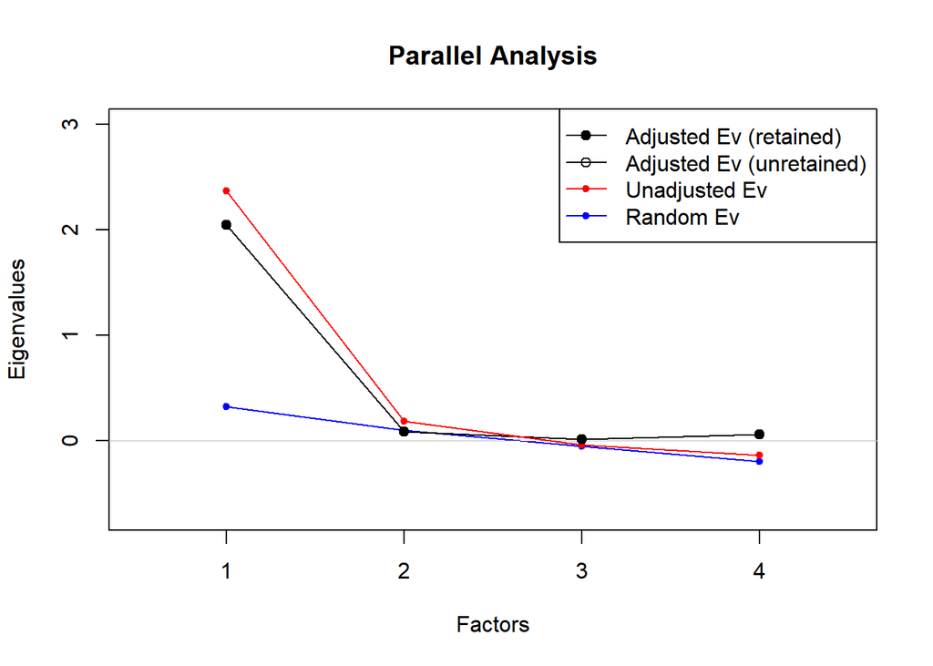

```r
paran(morpho, iterations = 5000, centile = 0, quietly = TRUE,
    status = FALSE, all = TRUE, cfa = TRUE, graph = TRUE, color = TRUE,
    col = c("black", "red", "blue"), lty = c(1, 2, 3), lwd = 1, legend = TRUE,
    file = "", width = 640, height = 640, grdevice = "png", seed = 0)
```

The results show that we would retain only PC1, which agrees with the Kaiser Criterion method.

# PCA on the Oak Woods Dataset - Robust PCA

The morphometric dataset we used here is virtually “ideal” for running a generic PCA in R. It contains no missing values, zeroes, extreme values or outliers. However, the Oak Woods dataset is characterized by extreme variability, outliers and zero values:

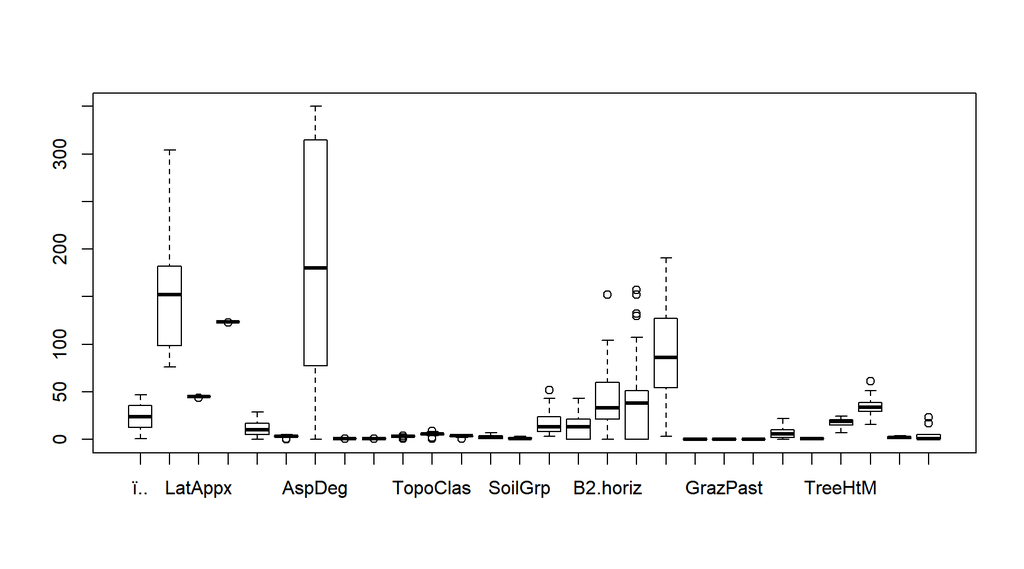

```r
load("OakWoods.Rdata")
boxplot(oak2)
```

As such, a prudent course would be to conduct a *robust PCA*.

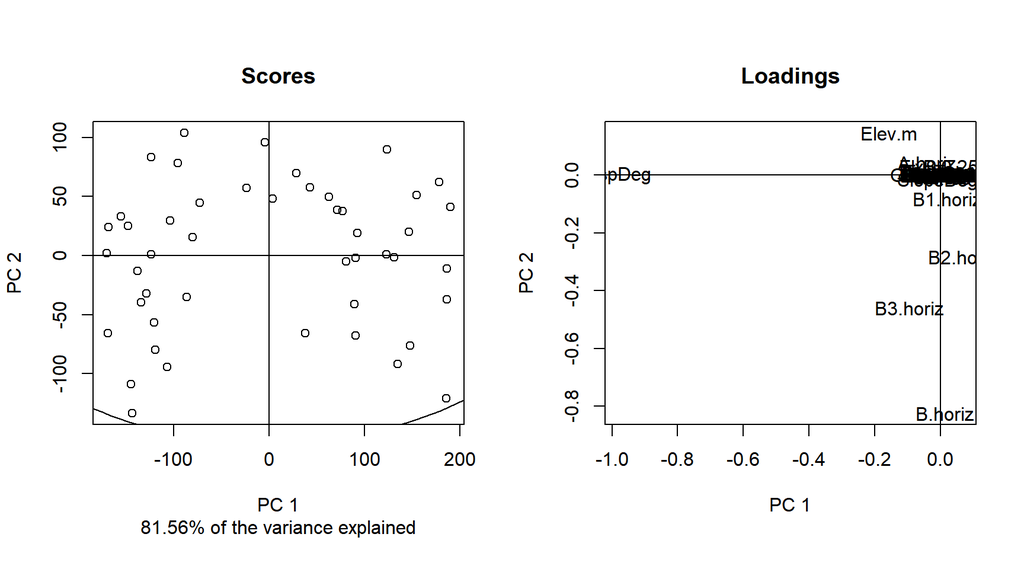

```r
# Save data frame as a matrix and eliminate the first column (character)
oak.matrix <- as.matrix(oak2[,-1])
pca_oak_robust <- pca(oak.matrix, method = "robustPca", nPcs = 27,
                      center = TRUE, scaled = TRUE)
slplot(pca_oak_robust)
```

```
##
## Using eigendecomposition of correlation matrix.
```

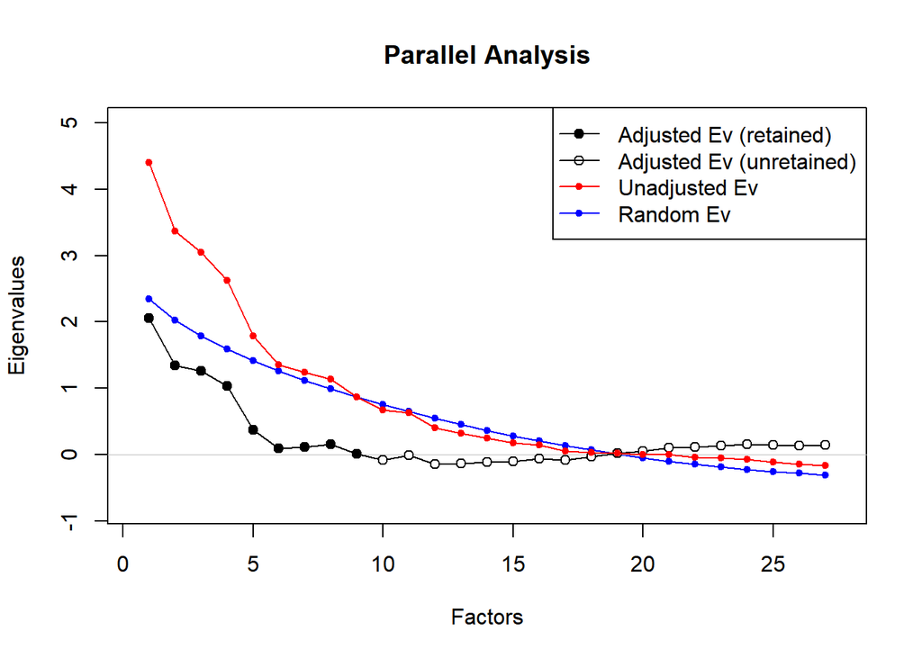

```r
paran(oak.matrix, iterations = 5000, centile = 0, quietly = TRUE,
    status = FALSE, all = TRUE, cfa = TRUE, graph = TRUE, color = TRUE,
    col = c("black", "red", "blue"), lty = c(1, 2, 3), lwd = 1, legend = TRUE,
    file = "", width = 640, height = 640, grdevice = "png", seed = 0)
```

In Summary, a PCA of any type may not be an appropriate statistical approach for this dataset. PCoA is a better choice with its built-in flexibility with respect to distance methods. Also, clustering based on any number of variables, such as `stand`, `Elev.m`, or `AspClass` would likely yield more meaningful results.